# Model checking

2024-01-26

## Agenda for today’s lecture

- **Objective of the Lecture:**

– Learn to check the main assumptions of regression

– Learn what are the implications of assumptions violations

– Learn how to address the assumptions violations

## Model Check

- The results that allow us to make inferences depending on model assumptions.
- Therefore, we need to make sure the assumptions are correct
- And what to do (if any) when they are not met.

## Residuals

- Most of the time, checking assumptions is all about working with residuals
- So, let’s first review the definition and then what are the expected properties of residuals
- Residuals definition:

The residuals for each observation \(i\) are the differences between the predicted values from the regression model \(\hat{y_i}\) and the observed values \(y_i\). These residuals are sometimes called \(\hat{e}\) to distinguish them from the population error, \(e\).

## Residuals Properties

The residuals will always have an expected value of zero, conditional on the predictors. Formally, \(\mathbb{E}[\hat{e}|X=x] = 0\).

If we assume homoskedasticity, they should have constant variance (which will rarely be the case).

Since it’s a sample, the probability of the residuals being completely uncorrelated among themselves is zero. However, the correlation should be low and converge to zero as \(n\) approaches infinity.

If we are assuming that the error follows a Gaussian (Normal) distribution, as in the Maximum Likelihood Estimation (MLE) model, the residuals should also be normally distributed.

## Residuals checking

We will try to check as many linear regression assumptions as possible I will run simulations to present each check We will learn How to interpret the results of the checking And what to do when the assumption is violated.

## Linearity assumption

## Residuals vs. Predictor

Since the residuals will have \(\mathbb{E}[\hat{e}|X=x] = 0\), it means that for each \(x_i\), the residuals should have an average of zero.

In a plot, this implies that if we have enough points near each \(x_i\), the dispersion of the residuals should appear random, without a clear pattern.

This results in a horizontal line with an average of zero. If not, there is probably some non-linearity.

## Residuals vs. Predictor (sim1)

```r
library(tidyverse)
library(ggplot2)

# set seed (for reproducibility)
set.seed(1234)
n <- 100
x <- rnorm(n)
e <- rnorm(n)
y <- 2 -1.5*x + 3*x^2 + e
df_sim <- data.frame(y=y, x=x, x_sq = x^2)
fit <-lm(y ~ x, df_sim)
```

## Residuals vs. Predictor (results1)

```r
summary(fit)
```

```
##
## Call:
## lm(formula = y ~ x, data = df_sim)
##
## Residuals:
##    Min     1Q Median     3Q    Max
## -6.110 -2.657 -1.316  1.467 14.690
##
## Coefficients:
##             Estimate Std. Error t value Pr(>|t|)
## (Intercept)   5.2398     0.3986  13.147   <2e-16 ***
## x            -0.6794     0.3940  -1.724   0.0878 .
## ---
## Signif. codes:  0 '***' 0.001 '**' 0.01 '*' 0.05 '.' 0.1 ' ' 1
##
## Residual standard error: 3.937 on 98 degrees of freedom
## Multiple R-squared:  0.02945,    Adjusted R-squared:  0.01954
## F-statistic: 2.973 on 1 and 98 DF,  p-value: 0.08779
```

## Residuals vs. Predictor (check1)

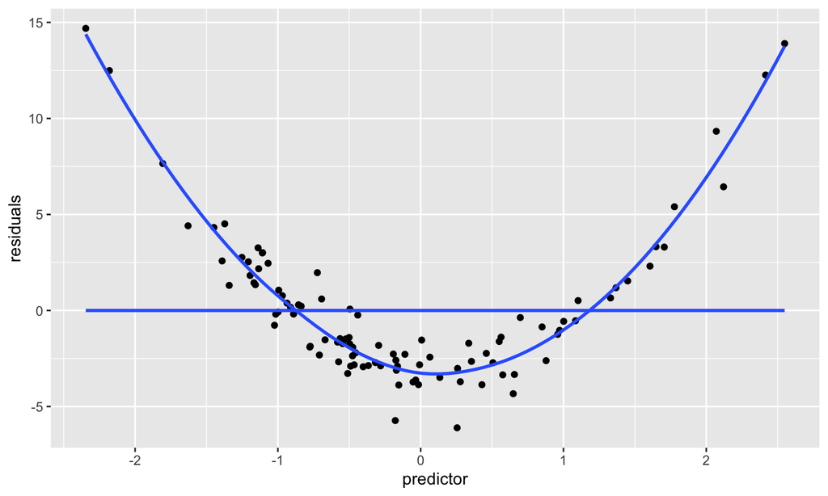

```r
df <- data.frame(residuals = residuals(fit), predictor = df_sim$x)
df %>%
  ggplot(aes(x=predictor, y = residuals)) + geom_point() +   geom_smooth(method="lm", se=F) +  geom_smooth(se=F)
```

## Residuals vs. Predictor (correction1)

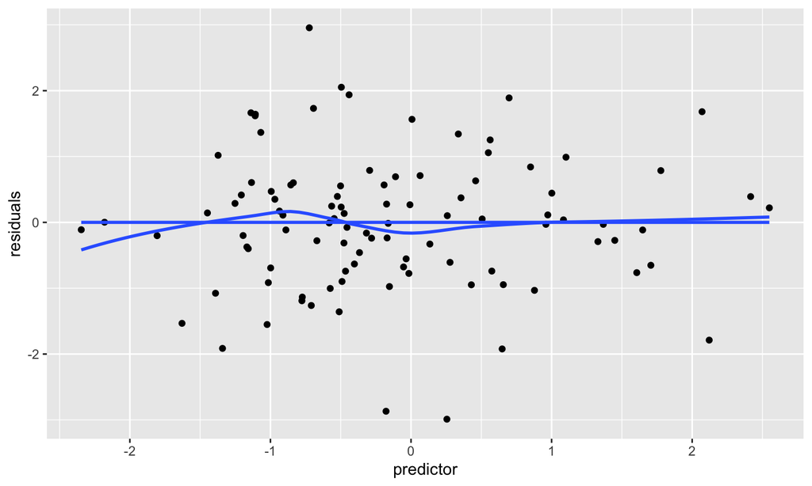

```r
fit_correct <-lm(y ~ x + x_sq, df_sim)
df <- data.frame(residuals = residuals(fit_correct), predictor = df_sim$x)
df %>%
  ggplot(aes(x=predictor, y = residuals)) + geom_point() +   geom_smooth(method="lm", se=F) + geom_smooth(se=F)
```

## Residuals vs. Predictor (sim2)

```r
# set seed (for reproducibility)
set.seed(1234)
n <- 100
x1 <- rnorm(n)
x <- .5*x1 + rnorm(n)
e <- rnorm(n)
y <- 2 -1.5*x + 3*x1 + e
df_sim2 <- data.frame(y=y, x=x, x1 = x1)
fit2 <-lm(y ~ x, df_sim2)
```

## Residuals vs. Predictor (results2)

```r
summary(fit2)
```

```
##
## Call:
## lm(formula = y ~ x, data = df_sim2)
##
## Residuals:
##     Min      1Q  Median      3Q     Max
## -7.7977 -2.0643 -0.1631  1.7920  8.1871
##
## Coefficients:
##             Estimate Std. Error t value Pr(>|t|)
## (Intercept)   1.7293     0.2945   5.872 5.89e-08 ***
## x            -0.2875     0.2603  -1.104    0.272
## ---
## Signif. codes:  0 '***' 0.001 '**' 0.01 '*' 0.05 '.' 0.1 ' ' 1
##
## Residual standard error: 2.943 on 98 degrees of freedom
## Multiple R-squared:  0.01229,    Adjusted R-squared:  0.002212
## F-statistic: 1.219 on 1 and 98 DF,  p-value: 0.2722
```

## Residuals vs. Predictor (check2)

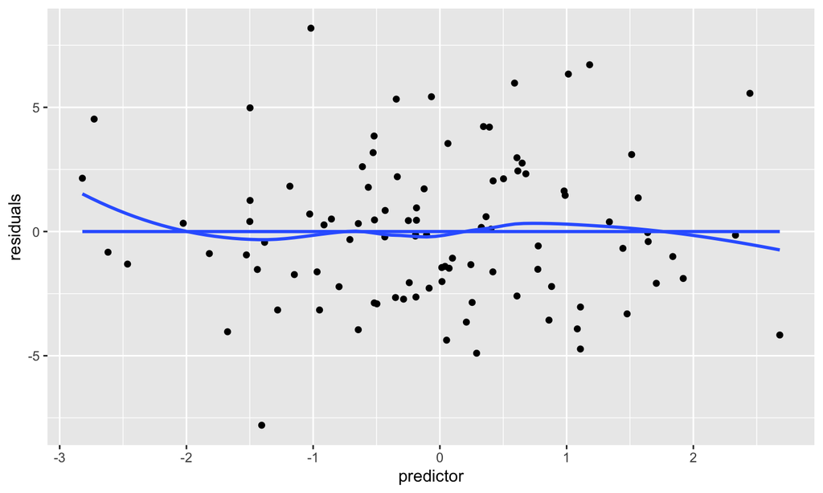

```r
df <- data.frame(residuals = residuals(fit2), predictor = df_sim2$x)
df %>%
  ggplot(aes(x=predictor, y = residuals)) + geom_point() +   geom_smooth(method="lm", se=F) + geom_smooth(se=F)
```

## Residuals vs. Predictor (correction2)

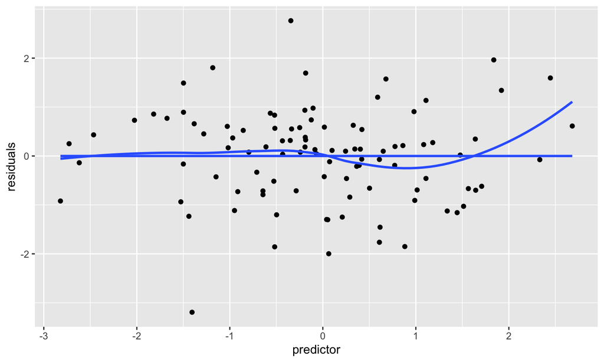

```r
fit_correct2 <-lm(y ~ x + x1, df_sim2)
df <- data.frame(residuals = residuals(fit_correct2), predictor = df_sim2$x)
df %>%
  ggplot(aes(x=predictor, y = residuals)) + geom_point() +   geom_smooth(method="lm", se=F)+ geom_smooth(se=F)
```

## Residuals vs. Predictor (sim3)

```r
set.seed(1234)
n <- 1000
x <- runif(n, 1, 1000)
e <- rnorm(n, 0, sd=1)
y <- 2 -3*log(x) + e
df_sim3 <- data.frame(y=y, x=x, log_x = log(x))
fit3 <-lm(y ~ x, df_sim3)
```

## Residuals vs. Predictor (results3)

```r
summary(fit3)
```

```
##
## Call:
## lm(formula = y ~ x, data = df_sim3)
##
## Residuals:
##     Min      1Q  Median      3Q     Max
## -4.0939 -1.0952 -0.2523  0.7325 14.2360
##
## Coefficients:
##               Estimate Std. Error t value Pr(>|t|)
## (Intercept) -1.120e+01  1.144e-01  -97.95   <2e-16 ***
## x           -9.031e-03  1.954e-04  -46.21   <2e-16 ***
## ---
## Signif. codes:  0 '***' 0.001 '**' 0.01 '*' 0.05 '.' 0.1 ' ' 1
##
## Residual standard error: 1.797 on 998 degrees of freedom
## Multiple R-squared:  0.6815, Adjusted R-squared:  0.6812
## F-statistic:  2135 on 1 and 998 DF,  p-value: < 2.2e-16
```

## Residuals vs. Predictor (check3)

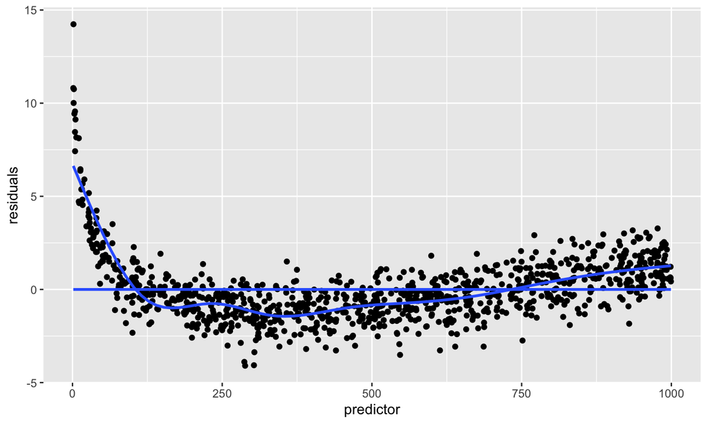

```r
df <- data.frame(residuals = residuals(fit3), predictor = df_sim3$x)
df %>%
  ggplot(aes(x=predictor, y = residuals)) + geom_point() +   geom_smooth(method="lm", se=F)+ geom_smooth(se=F)
```

## Residuals vs. Predictor (correction3)

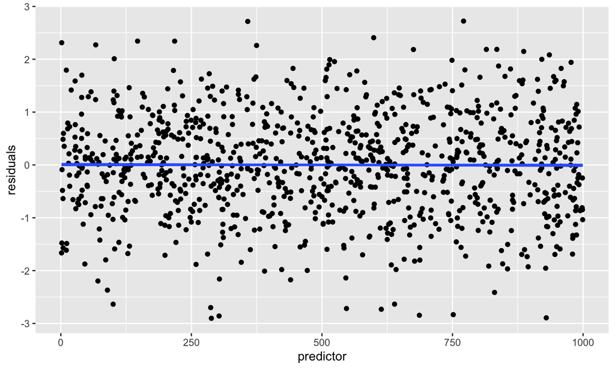

```r
fit_correct3 <-lm(y ~ log_x, df_sim3)
df <- data.frame(residuals = residuals(fit_correct3), predictor = df_sim3$x)
df %>%
  ggplot(aes(x=predictor, y = residuals)) + geom_point() +   geom_smooth(method="lm", se=F)+ geom_smooth(se=F)
```

## Homoskedasticity assumption

## Magnitude of Residuals vs. Predictor

Given that \(\mathbb{E}[\hat{e}|X] = 0\), it follows that \(\mathbb{Var}[\hat{e}|X] = \mathbb{E}[\hat{e}^2|X]\).

Therefore, if we assume homoskedasticity, i.e., that \(\mathbb{Var}[\hat{e}|X] = \sigma^2\), we can check this assumption by looking at the conditional expectation of the squared residuals.

We can do this by plotting the squared residuals against the predictor.

Bear in mind this plot only looks at the conditional expectation, not the unconditional expectation.

## Squared Residuals vs. Predictor (sim1)

```r
library(tidyverse)
library(ggplot2)

set.seed(1234)
n <- 100
x <- rnorm(n)
e <- rnorm(n)
y <- 2 -1.5*x + 3*x^2 + e
df_sim <- data.frame(y=y, x=x, x_sq = x^2)
fit <-lm(y ~ x, df_sim)
```

## Squared Residuals vs. Predictor (results1)

```r
summary(fit)
```

```
##
## Call:
## lm(formula = y ~ x, data = df_sim)
##
## Residuals:
##    Min     1Q Median     3Q    Max
## -6.110 -2.657 -1.316  1.467 14.690
##
## Coefficients:
##             Estimate Std. Error t value Pr(>|t|)
## (Intercept)   5.2398     0.3986  13.147   <2e-16 ***
## x            -0.6794     0.3940  -1.724   0.0878 .
## ---
## Signif. codes:  0 '***' 0.001 '**' 0.01 '*' 0.05 '.' 0.1 ' ' 1
##
## Residual standard error: 3.937 on 98 degrees of freedom
## Multiple R-squared:  0.02945,    Adjusted R-squared:  0.01954
## F-statistic: 2.973 on 1 and 98 DF,  p-value: 0.08779
```

## Squared Residuals vs. Predictor (check1)

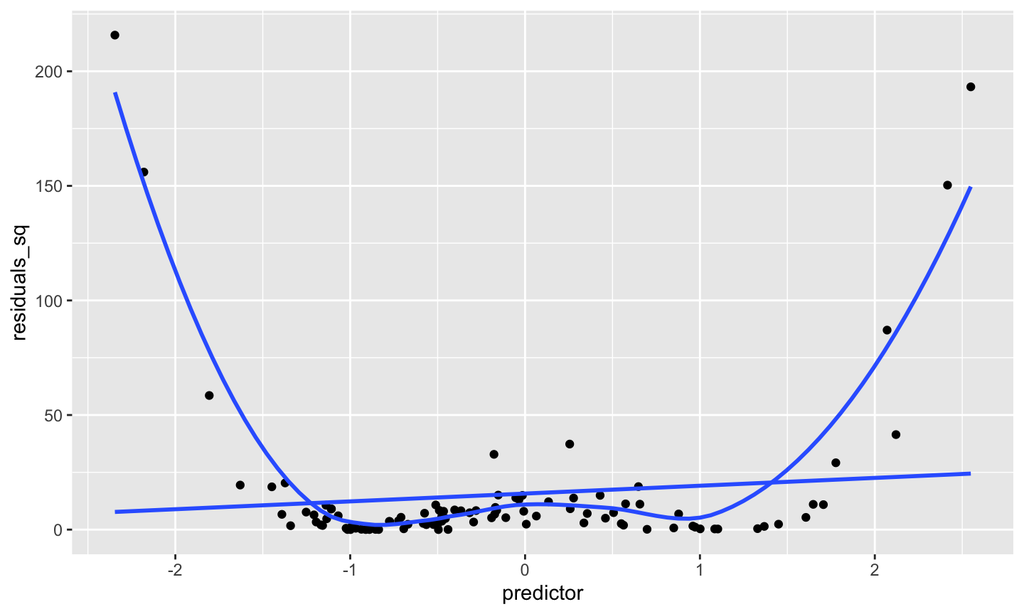

```r
df <- data.frame(residuals_sq = residuals(fit)^2, predictor = df_sim$x)
df %>%
  ggplot(aes(x=predictor, y = residuals_sq)) + geom_point() +   geom_smooth(method="lm", se=F) + geom_smooth(se=F)
```

## Squared Residuals vs. Predictor (correction1)

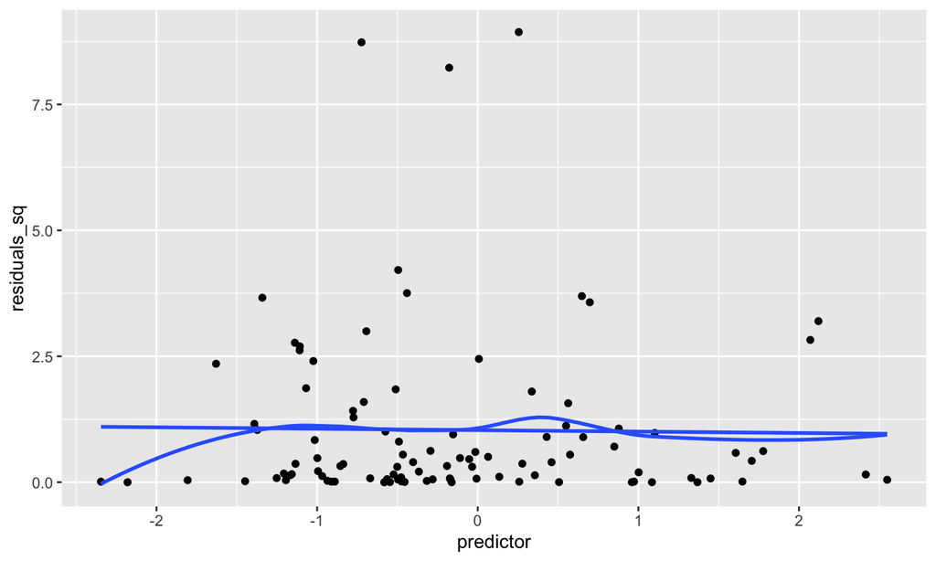

```r
fit_correct <-lm(y ~ x + x_sq, df_sim)
df <- data.frame(residuals_sq = residuals(fit_correct)^2, predictor = df_sim$x)
df %>%
  ggplot(aes(x=predictor, y = residuals_sq)) + geom_point() +   geom_smooth(method="lm", se=F) + geom_smooth(se=F)
```

## Squared Residuals vs. Predictor (sim2)

```r
set.seed(1234)
n <- 100
x1 <- rnorm(n)
x <- .5*x1 + rnorm(n)
e <- rnorm(n)
y <- 2 -1.5*x + 3*x1 + e
df_sim2 <- data.frame(y=y, x=x, x1 = x1)
fit2 <-lm(y ~ x, df_sim2)
```

## Squared Residuals vs. Predictor (results2)

```r
summary(fit2)
```

```
##
## Call:
## lm(formula = y ~ x, data = df_sim2)
##
## Residuals:
##     Min      1Q  Median      3Q     Max
## -7.7977 -2.0643 -0.1631  1.7920  8.1871
##
## Coefficients:
##             Estimate Std. Error t value Pr(>|t|)
## (Intercept)   1.7293     0.2945   5.872 5.89e-08 ***
## x            -0.2875     0.2603  -1.104    0.272
## ---
## Signif. codes:  0 '***' 0.001 '**' 0.01 '*' 0.05 '.' 0.1 ' ' 1
##
## Residual standard error: 2.943 on 98 degrees of freedom
## Multiple R-squared:  0.01229,    Adjusted R-squared:  0.002212
## F-statistic: 1.219 on 1 and 98 DF,  p-value: 0.2722
```

## Squared Residuals vs. Predictor (check2)

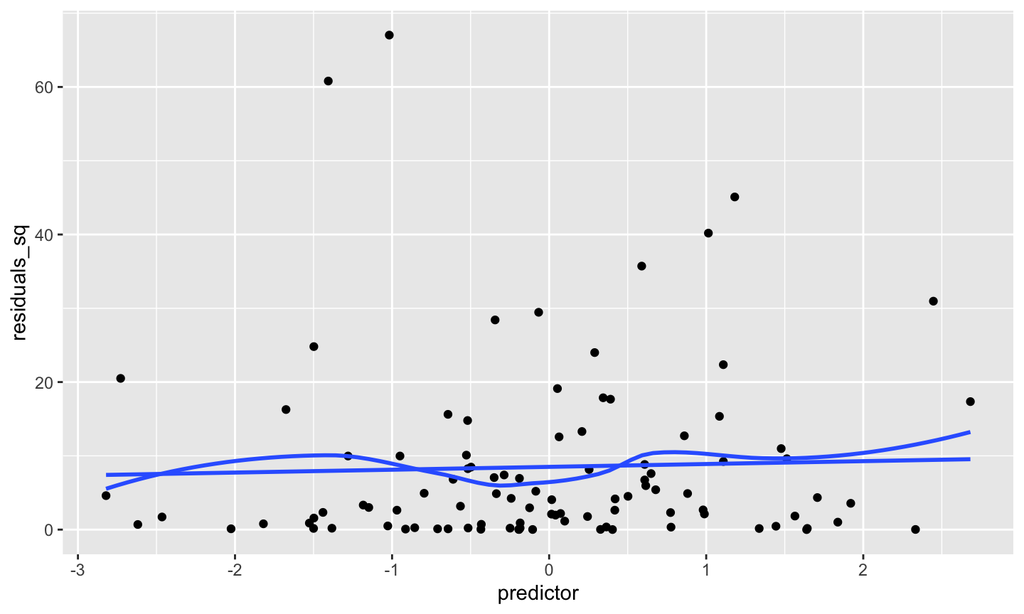

```r
df <- data.frame(residuals_sq = residuals(fit2)^2, predictor = df_sim2$x)
df %>%
  ggplot(aes(x=predictor, y = residuals_sq)) + geom_point() +   geom_smooth(method="lm", se=F) + geom_smooth(se=F)
```

## Squared Residuals vs. Predictor (correction2)

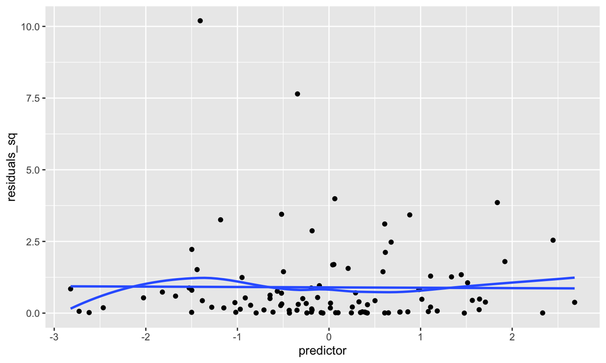

```r
fit_correct2 <-lm(y ~ x + x1, df_sim2)
df <- data.frame(residuals_sq = residuals(fit_correct2)^2, predictor = df_sim2$x)
df %>%
  ggplot(aes(x=predictor, y = residuals_sq)) + geom_point() +   geom_smooth(method="lm", se=F) + geom_smooth(se=F)
```

## Squared Residuals vs. Predictor (sim3)

```r
set.seed(1234)
n <- 1000
x <- runif(n, 1, 1000)
e <- rnorm(n, 0, sd=1)
y <- 2 -3*log(x) + e
df_sim3 <- data.frame(y=y, x=x, log_x = log(x))
fit3 <-lm(y ~ x, df_sim3)
```

## Squared Residuals vs. Predictor (results3)

```r
summary(fit3)
```

```
##
## Call:
## lm(formula = y ~ x, data = df_sim3)
##
## Residuals:
##     Min      1Q  Median      3Q     Max
## -4.0939 -1.0952 -0.2523  0.7325 14.2360
##
## Coefficients:
##               Estimate Std. Error t value Pr(>|t|)
## (Intercept) -1.120e+01  1.144e-01  -97.95   <2e-16 ***
## x           -9.031e-03  1.954e-04  -46.21   <2e-16 ***
## ---
## Signif. codes:  0 '***' 0.001 '**' 0.01 '*' 0.05 '.' 0.1 ' ' 1
##
## Residual standard error: 1.797 on 998 degrees of freedom
## Multiple R-squared:  0.6815, Adjusted R-squared:  0.6812
## F-statistic:  2135 on 1 and 998 DF,  p-value: < 2.2e-16
```

## Squared Residuals vs. Predictor (check3)

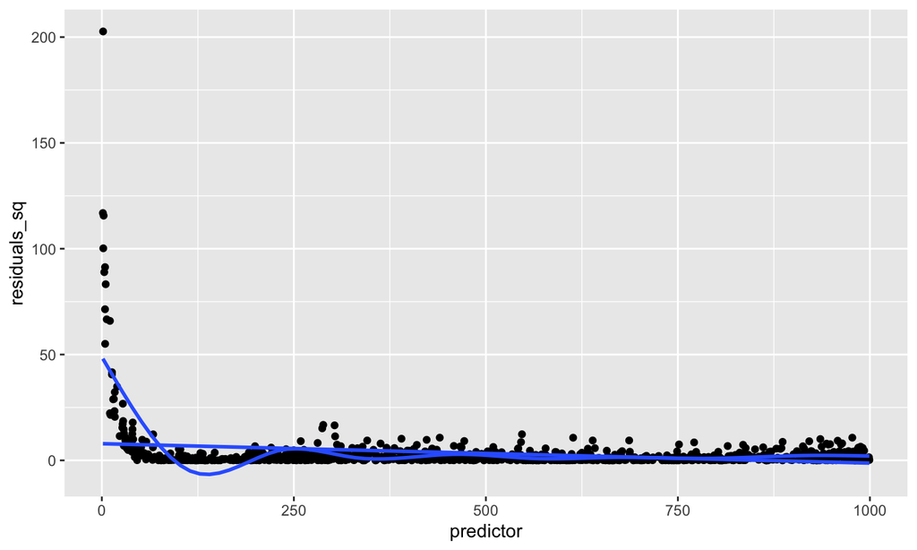

```r
df <- data.frame(residuals_sq = residuals(fit3)^2, predictor = df_sim3$x)
df %>%
  ggplot(aes(x=predictor, y = residuals_sq)) + geom_point() +geom_smooth(method="lm", se=F) + geom_smooth(se=F)
```

## Squared Residuals vs. Predictor (correction3)

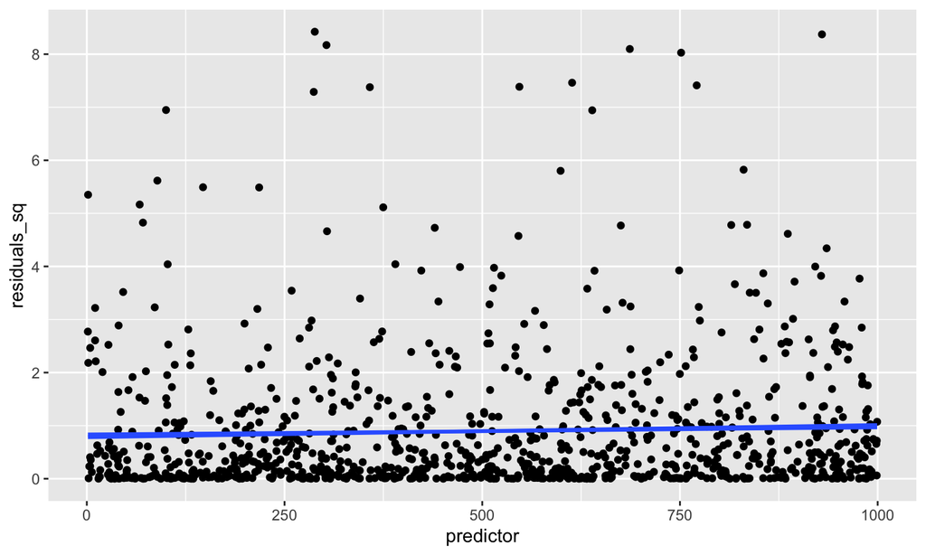

```r
fit_correct3 <-lm(y ~ log_x, df_sim3)
df <- data.frame(residuals_sq = residuals(fit_correct3)^2, predictor = df_sim3$x)
df %>%
  ggplot(aes(x=predictor, y = residuals_sq)) + geom_point() +   geom_smooth(method="lm", se=F) + geom_smooth(se=F)
```

## Squared Residuals vs. Predictor (sim4)

```r
set.seed(1234)
n <- 1000
x <- rnorm(n)
sigma <- runif(n, min=1, max=20)
e <- rnorm(n, 0, sd=sigma)
y <- 2 -.5*x + e
df_sim4 <- data.frame(y=y, x=x)
fit4 <-lm(y ~ x, df_sim4)
```

## Squared Residuals vs. Predictor (results4)

```r
summary(fit4)
```

```
##
## Call:
## lm(formula = y ~ x, data = df_sim4)
##
## Residuals:
##     Min      1Q  Median      3Q     Max
## -43.356  -6.022   0.071   5.931  57.894
##
## Coefficients:
##             Estimate Std. Error t value Pr(>|t|)
## (Intercept)   2.0996     0.3919   5.357 1.05e-07 ***
## x            -0.6156     0.3930  -1.566    0.118
## ---
## Signif. codes:  0 '***' 0.001 '**' 0.01 '*' 0.05 '.' 0.1 ' ' 1
##
## Residual standard error: 12.39 on 998 degrees of freedom
## Multiple R-squared:  0.002452,   Adjusted R-squared:  0.001453
## F-statistic: 2.453 on 1 and 998 DF,  p-value: 0.1176
```

## Squared Residuals vs. Predictor (check4)

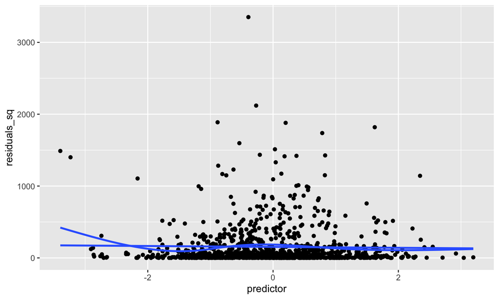

```r
df <- data.frame(residuals_sq = residuals(fit4)^2, predictor = df_sim4$x)
df %>%
  ggplot(aes(x=predictor, y = residuals_sq)) + geom_point() +geom_smooth(method="lm", se=F) + geom_smooth(se=F)
```

## Squared Residuals vs. Predictor (correction4)

```r
library(lmtest)
library(sandwich)
coeftest(fit4, vcov = vcovHC(fit4, "HC3"))
```

```
##
## t test of coefficients:
##
##             Estimate Std. Error t value  Pr(>|t|)
## (Intercept)  2.09960    0.39184  5.3583 1.043e-07 ***
## x           -0.61558    0.38054 -1.6176    0.1061
## ---
## Signif. codes:  0 '***' 0.001 '**' 0.01 '*' 0.05 '.' 0.1 ' ' 1
```

```r
coeftest(fit4, vcov = vcovHC(fit4, "HC1"))
```

```
##
## t test of coefficients:
##
##             Estimate Std. Error t value  Pr(>|t|)
## (Intercept)  2.09960    0.39148  5.3632 1.016e-07 ***
## x           -0.61558    0.37880 -1.6251    0.1045
## ---
## Signif. codes:  0 '***' 0.001 '**' 0.01 '*' 0.05 '.' 0.1 ' ' 1
```

## Squared Residuals vs. Predictor (sim5)

```r
# Error variance is not constant - adaptad from https://rpubs.com/EmilOWK/heteroscedasticity
library(plyr) # mapvalues function
set.seed(123)
n <- 100
HS_strength <- 5
library(purrr)
df <- tibble(
  id = 1:n,
  x = seq(0, 10, length.out = n),
  y_noHS = x * 1 + rnorm(n),
  y_linHS = x * 1 + rnorm(n)*seq(1, HS_strength, length.out = n),
  y_nonlinHS = x * 1 + rnorm(n)*c(seq(HS_strength, 1, length.out = n/2),
                                     seq(1, HS_strength, length.out = n/2))) %>%
  pivot_longer(cols = -c(x,id)) %>%
  mutate(    name = factor(name %>% mapvalues(c("y_noHS", "y_linHS", "y_nonlinHS"),
                                              c("no HS", "linear HS", "nonlinear HS")),
                           levels = c("no HS", "linear HS", "nonlinear HS"))) %>%
  dplyr::rename(y = value)
fit5.1 <- lm(y ~x, data=dplyr::filter(df, name == "no HS"))
fit5.2 <- lm(y ~x, data=dplyr::filter(df, name == "linear HS"))
fit5.3 <- lm(y ~x, data=dplyr::filter(df, name == "nonlinear HS"))
```

## Squared Residuals vs. Predictor (results5)

```r
library(stargazer)

stargazer(fit5.1, fit5.2, fit5.3, type = "html")
```

|  | *Dependent variable:* |  |  |
| --- | --- | --- | --- |
|  | y |  |  |
|  | (1) | (2) | (3) |
| x | 1.025*** | 1.012*** | 1.133*** |
|  | (0.031) | (0.108) | (0.109) |
| Constant | -0.034 | -0.275 | -0.121 |
|  | (0.182) | (0.626) | (0.628) |
| Observations | 100 | 100 | 100 |
| R<sup>2</sup> | 0.916 | 0.472 | 0.526 |
| Adjusted R<sup>2</sup> | 0.915 | 0.467 | 0.521 |
| Residual Std. Error (df = 98) | 0.915 | 3.153 | 3.166 |
| F Statistic (df = 1; 98) | 1,067.661*** | 87.583*** | 108.817*** |
| *Note:* | p<0.1; p<0.05; p<0.01 |  |  |

## Squared Residuals vs. Predictor (check5)

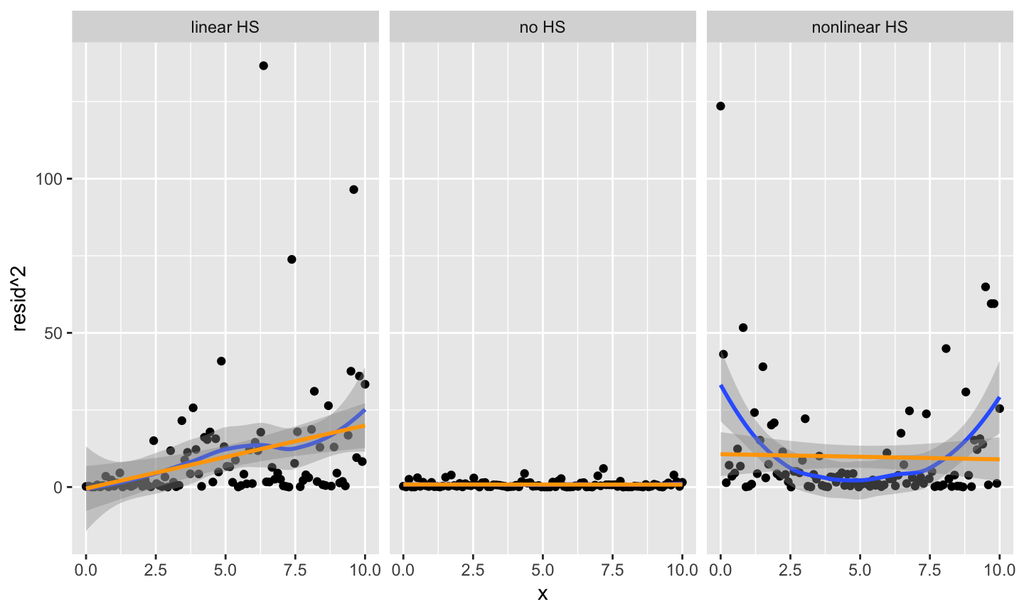

```r
df %>%
  ggplot(aes(x, resid^2)) +
  geom_point() +
  geom_smooth() +
  geom_smooth(method = "lm", color = "orange") +
  facet_wrap("name")
```

## Squared Residuals vs. Predictor (correction5)

```r
library(lmtest)
library(sandwich)
obj1 <- coeftest(fit5.1, vcov. = vcovHC(fit5.1, "HC3"))
obj2 <- coeftest(fit5.2, vcov. = vcovHC(fit5.2, "HC3"))
obj3 <- coeftest(fit5.3, vcov. = vcovHC(fit5.3, "HC3"))

stargazer(obj1, obj2, obj2, type = "html")
```

|  | *Dependent variable:* |  |  |
| --- | --- | --- | --- |
|  | (1) | (2) | (3) |
| x | 1.025*** | 1.012*** | 1.012*** |
|  | (0.033) | (0.110) | (0.110) |
| Constant | -0.034 | -0.275 | -0.275 |
|  | (0.189) | (0.435) | (0.435) |
| *Note:* | p<0.1; p<0.05; p<0.01 |  |  |

## Normality Assumption

## Normality of Residuals

If we assume normality of the residuals, we can check if they are indeed normal.

One way to do this is by plotting the histogram of the residuals and overlaying the density of a normal distribution with a mean of zero (residuals have a mean of zero) and a standard deviation equal to the standard deviation of the residuals.

## Q-Q Plots for Normality Check

- A more traditional alternative for checking normality is the use of Q-Q plots, which stands for “quantile-quantile” plots.
- The quantile function tells us the point that divides our probability distribution at exactly \(p\%\).
- For example, we can find the point that divides our data exactly in half (median), or at the first quartile, first percentile, in short, at any percentile of the distribution.
- R has a function for this purpose, which is worth exploring to gain a better understanding.

## Squared Residuals vs. Predictor (sim6)

```r
set.seed(1234)
n <- 1000
x <- runif(n)
e <- runif(n)
y <- 2 - x + e
df_sim6 <- data.frame(y=y, x=x)
fit6 <-lm(y ~ x, df_sim6)
```

## Results (results6)

```r
summary(fit6)
```

```
##
## Call:
## lm(formula = y ~ x, data = df_sim6)
##
## Residuals:
##      Min       1Q   Median       3Q      Max
## -0.48991 -0.24537 -0.00016  0.23299  0.51535
##
## Coefficients:
##             Estimate Std. Error t value Pr(>|t|)
## (Intercept)   2.4728     0.0179  138.16   <2e-16 ***
## x            -0.9735     0.0306  -31.81   <2e-16 ***
## ---
## Signif. codes:  0 '***' 0.001 '**' 0.01 '*' 0.05 '.' 0.1 ' ' 1
##
## Residual standard error: 0.2817 on 998 degrees of freedom
## Multiple R-squared:  0.5034, Adjusted R-squared:  0.5029
## F-statistic:  1012 on 1 and 998 DF,  p-value: < 2.2e-16
```

## histogram for Normality Check (results6a)

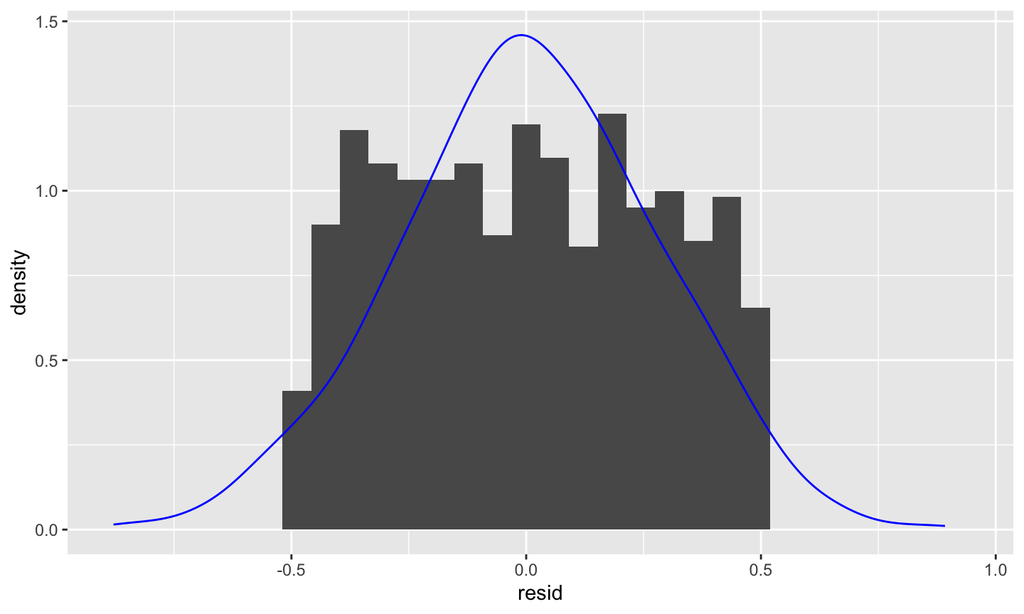

```r
df <- data.frame(resid = residuals(fit6), x = df_sim6$x,
                 density_points = rnorm(length(residuals(fit6)) , 0, sd(residuals(fit6))))

df %>%
  ggplot(aes(resid)) +
  geom_histogram(aes(y = after_stat(density))) +  geom_density(aes(density_points), colour = "blue")
```

## Q-Q Plots for Normality Check (results6a)

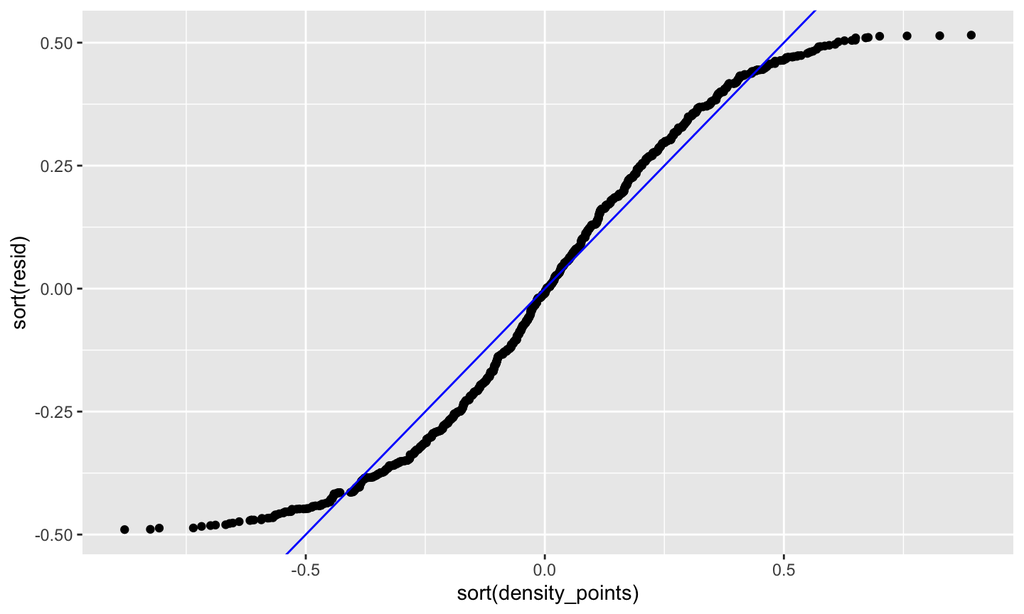

```r
df %>%
  ggplot(aes(y=sort(resid), x=sort(density_points))) + geom_point() +
  geom_abline(intercept = 0, slope = 1, colour ="blue")
```

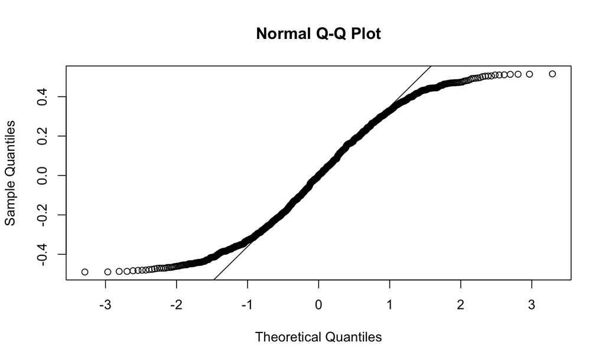

```r
qqnorm(residuals(fit6))
qqline(residuals(fit6))
```

## Quick check of everything

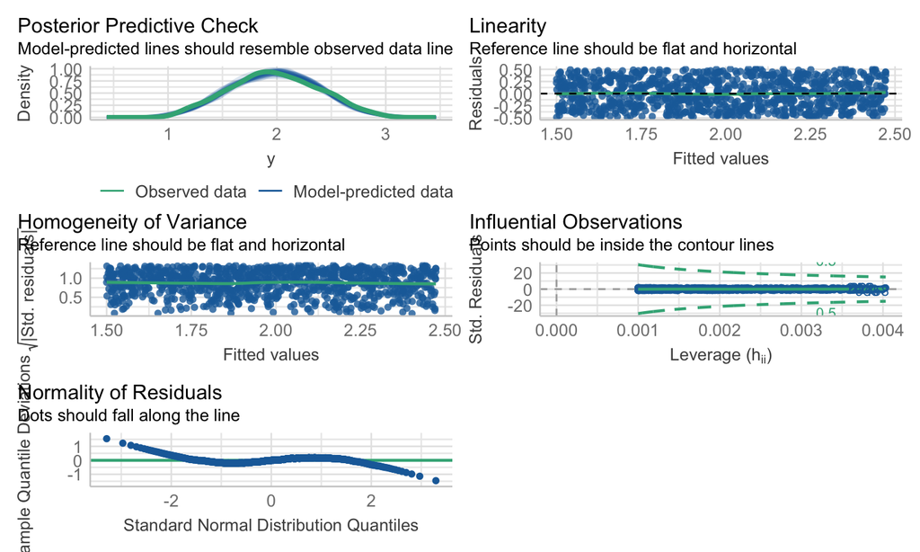

```r
library(performance)
check_model(fit6)
```